[AIPLA](https://aipla.ku.dk/) [All guides](https://aipla.ku.dk/guides) [About the project](https://aipla.ku.dk/project) AI in Physics Learning and Assessment · Københavns Universitet

# Opret en klasse og del den

AIPLA lærervejledning — T1

Forfatter

AIPLA project team

Udgivet

14. juli 2026

**Hvor dette passer ind**

En **klasse** er udgangspunktet for alt det øvrige. Den rummer dine elever (som anonyme grupper, uden personlige konti) og de aktiviteter, du bygger til dem. Dette gør du én gang pr. klasse; det tager cirka tre minutter. Bagefter følger du *T2 — Opret din første aktivitet*.

## Hvad en klasse er

I AIPLA er en **klasse** en beholder, som du ejer. Den har:

- en eller flere **gruppekoder** — de korte koder, som eleverne indtaster for at tilslutte sig. Eleverne opretter ikke konti og logger ikke ind; gruppekoden er alt, hvad de behøver.
- de **aktiviteter**, du tildeler den (vejledning *T2*).
- en **tutor** — den, der underviser klassen: navn, billede, stemme, tone og undervisningstilgang i ét valg. Lad standarden stå, eller skift den senere.

Alt nedenfor gøres i din browser. Du behøver ikke en udvikler.

**Medbyggeren kan gøre dette for dig**

Klasselisten har et panel med en AI-**medbygger**. Du kan oprette en klasse og udstede gruppekoder ved at bede den om det i almindeligt sprog, i stedet for at bruge formularerne nedenfor — se *T4 — Byg med AI-medbyggeren*.

## Trin 1 — Opret klassen

Fra dit lærerområde åbner du **Classes** og vælger **New class**. Giv klassen et **navn** — for eksempel *“Fysik 2.g, efterår 2026”* — og eventuelt en kort beskrivelse. Vælg **Create**.

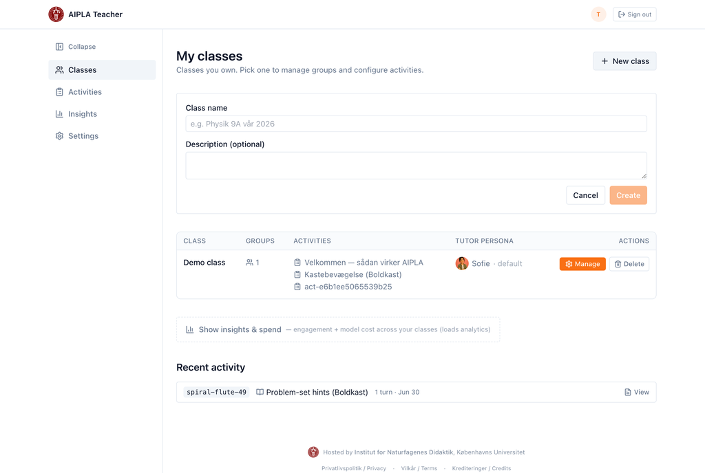

Formularen New class: et navn og en valgfri beskrivelse.

Din nye klasse vises nu på klasselisten, sammen med eventuelle andre, du ejer.

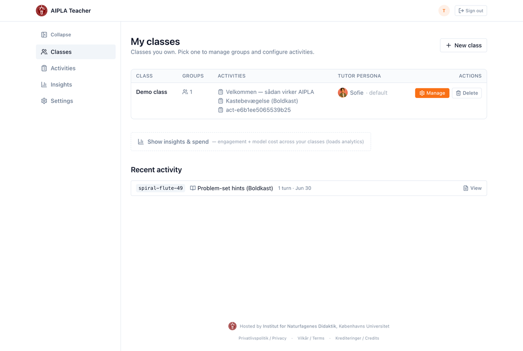

## Trin 2 — Udsted en gruppekode

Åbn klassen med **Manage**. En ny klasse har endnu ingen gruppekoder, så vælg **New group**. AIPLA genererer en kort kode og kopierer den til din udklipsholder.

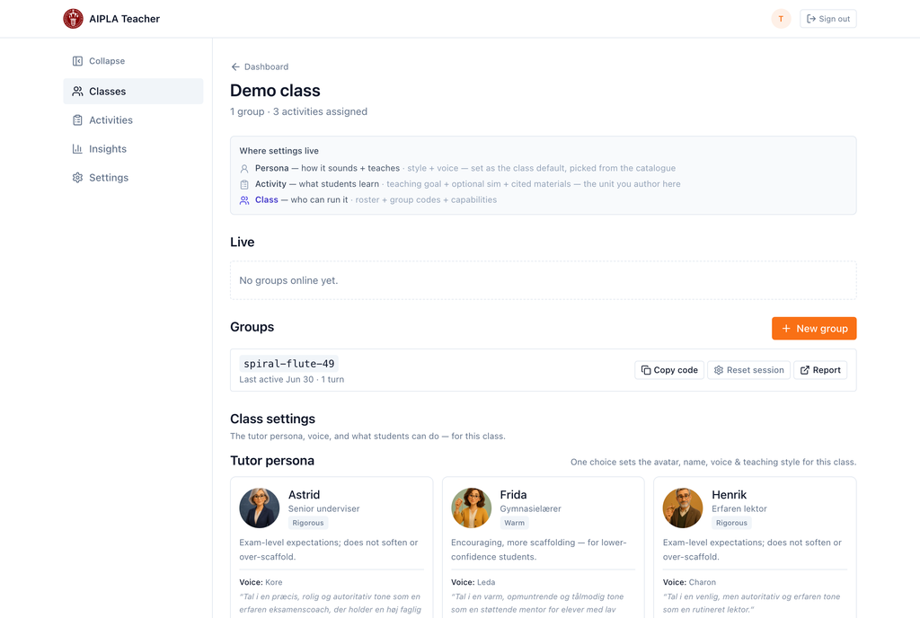

Ved at vælge New group udstedes en kode, eleverne bruger til at tilslutte sig.

Du kan udstede mere end én gruppekode til den samme klasse — for eksempel én pr. bordgruppe eller pr. laboratoriepar — så du kan skelne deres arbejde fra hinanden i rapporterne.

## Trin 3 — Del koden med eleverne

Giv eleverne gruppekoden. De åbner elevlinket, indtaster koden, og så er de inde — ingen login, ingen personlig konto (se *S1 — Tilslut dig og brug din tutor*). Alt, hvad de foretager sig, grupperes under den kode, så dine klasserapporter forbliver organiserede.

**Tip**

Gruppekoder er måden, hvorpå du adskiller én klasse — eller én laboratoriegruppe — fra en anden i rapporterne. Udsted en frisk kode for hver gruppe, du vil følge separat.

## Næste skridt

- Byg den første aktivitet til denne klasse — *T2 — Opret din første aktivitet*.
- Tilføj pensummaterialer, som tutoren kan trække på — *T3 — Tilføj og organisér pensummaterialer*.